# Final Project

today

```r
library(dplyr)
library(ggplot2)
library(tm)
library(textshape)
library(lexicon)
library(textclean)
library(broom)
library(tidytext)
library(gridExtra)
library(tidyverse)
library(caret)
library(caTools)
library(ROCR)
library(rpart)
library(rpart.plot)
library(ISLR)
```

## Import

```r
support <- read.csv(file = "/Users/zixuan zhu/Desktop/users.csv")
tweet <- read.csv(file = "/Users/zixuan zhu/Desktop/tweets_debate3.csv")
#samp<-sample(nrow(tweet),5000)
#tweet<-tweet[samp,]
#head(tweet)
```

```r
tweet<-merge(tweet , support )
#subset(tweet, follow_candidate!="NAN", select=-c(location))
tweet<- subset(tweet, follow_candidate!="NAN", select=c(userID, text,follow_candidate))
#head(tweet)
```

```r
set.seed(42)
select = 1000

T_tweet<-tweet%>%filter(follow_candidate=='trump')
C_tweet<-tweet%>%filter(follow_candidate=='clinton')
#T_tweet
#C_tweet

t_exp = sample(nrow(T_tweet),select)
c_exp = sample(nrow(C_tweet),select)
t = T_tweet[t_exp ,]
#t
c = C_tweet[c_exp ,]
#c
rows <- sample(2*select)
tweet_exp<-rbind(t,c)
#dim(exp_data)
tweet_exp <- tweet_exp[rows, ]
##50% trump ---- 50% clinton
```

```r
#index = which(tweet$userID ==c(tweet_exp$userID) )
```

##The first feature–TDM(TF-IDF) ###preprocessing

```r
# initial clean
a=gsub("RT ","",tweet_exp$text)
a = gsub("&amp", "", a)
a = gsub("@HillaryClinton", "HIllAryClinton", a)
a = gsub("@realDonaldTrump", "DONaldTrump", a)
a=replace_tag(a)
a = gsub("@\\w+", "", a)
a=gsub("#","",a)
a=replace_url(a)
a=replace_emoji(a)
a=replace_html(a)
a=replace_white(a)
a=replace_word_elongation(a)
a = gsub(":", "", a)
a = gsub("[[:punct:]]", "", a)
#replace_emoji(support_tweet$text[1])
#lapply(support_tweet$text,replace_emoji)
#replace_symbol(support_tweet$text, remove=TRUE)
tweet_exp$text=a
index=1-c(is.na(tweet_exp$text))  # remove NA row, generated after text clean
tweet_exp=tweet_exp[index==1,]
```

```r
CleanCorpus <- function(x){
    x <- tm_map(x, content_transformer(tolower))
     x <- tm_map(x, removeNumbers) #remove numbers before removing words. Otherwise "trump2016" leaves "trump"
     #x <- tm_map(x, removeWords, tidytext::stop_words$word)
     x <- tm_map(x, removeWords, tidytext::stop_words$word)
     x <- tm_map(x, removePunctuation)
   # x <- tm_map(x, function(x) removeWords(x, stopwords("english")))
     x <- tm_map(x, removeWords, c("debate", 'debates',"debatenight",'tonight','support'))
     x <- tm_map(x, removeWords, tidytext::stop_words$word)
    x<-tm_map(x, stemDocument, language = "english")
   x <- tm_map(x, removeWords, tidytext::stop_words$word)

      x <- tm_map(x, stripWhitespace)



     return(x)
}

RemoveNames <- function(x) {
       x <- tm_map(x, removeWords, c("donald", "hillary", "clinton", "trump", "realdonaldtrump", "hillaryclinton",'hilary','hillaryclinton','donaldtrump','hillari','hllaryclinton','hilari'))
       return(x)
}


Trump=c("donald", "trumps", "trump", "realdonaldtrump", 'donaldtrump')
Clinton=c("hillary", "clinton",  "hillaryclinton",'hilary','hillari')

CreateTermsMatrix <- function(x) {
        x <- TermDocumentMatrix(x)
        x <- as.matrix(x)
        y <- rowSums(x)
        y <- sort(y, decreasing=TRUE)
        return(y)
}
```

```r
f1corpus = Corpus(VectorSource(tweet_exp$text))
f1corpus = CleanCorpus(f1corpus)
f1corpus=RemoveNames(f1corpus)
```

###term-Document Matrix

```r
td.mat = as.matrix(TermDocumentMatrix(f1corpus))
#td.mat[1:3,]
dim(td.mat)
```

```
## [1] 2910 1976
```

### TF-IDF

```r
library(tm)
library(lsa)
library(SnowballC)
td.mat.w = lw_tf(td.mat) * gw_idf(td.mat)  ## tf-idf weighting
```

##Model ###K-means

```r
set.seed(1)
kfit<-kmeans(t(td.mat.w), centers=2, nstart=10)
```

```r
cluster<-cbind(tweet_exp,pred=kfit$cluster)

tab<-table(kfit$cluster,tweet_exp$follow_candidate)
tab
```

```
##
##     clinton trump
##   1     987   985
##   2       2     2
```

```r
sum(diag(tab))/sum(rowSums(tab))
```

```
## [1] 0.5005061
```

```r
#Accuracy: 0.5005061
#Sensitivity: 2/(2+2) = 0.5
#Specificity: 987/(987+985) = 0.5005071
#F1 score: 2*(0.5 * 0.5005071)/(0.5 + 0.5005071) = 0.5002534
```

```r
conclusion <- matrix(c(0.5005061,0.5,0.5005071,0.5002534),ncol=4,byrow=TRUE)
colnames(conclusion) <- c("Accuracy","Sensitivity",
                     "Specificity",
                     "F1 score")
rownames(conclusion) <- 'Kmeans'
conclusion <- as.table(conclusion)
conclusion
```

```
##         Accuracy Sensitivity Specificity  F1 score
## Kmeans 0.5005061   0.5000000   0.5005071 0.5002534
```

###SVM

```r
library(e1071)
#samp<-sample(nrow(tweet_exp),0.8*nrow(tweet_exp))
svm<-data.frame(label=tweet_exp$follow_candidate,t(td.mat.w))
```

```r
library(rsample)

svm$label = ifelse(svm$label=="clinton", 0 , 1)

svm$label <- factor(svm$label)

set.seed(1)
split <- initial_split(svm, prop = 0.8,
                       strata = 'label')
set.seed(1)
train <- training(split)
set.seed(1)
test <- testing(split)

set.seed(1)
model = svm(label ~ ., data = train,
              kernel = "linear")
```

```r
set.seed(1)
svm_pre<-predict(model,test)

tab<-table(svm_pre,test$label)
#table(tweet[-samp,]$follow_candidate)
tab
```

```
##
## svm_pre   0   1
##       0 136  90
##       1  61 107
```

```r
sum(diag(tab))/sum(rowSums(tab))
```

```
## [1] 0.6167513
```

```r
# Accuracy: 0.6167513
# Sensitivity: 107/(107+61) = 0.6369048
# Specificity: 136/(136+90) = 0.6017699
# F1 score: 2*(0.6369048 * 0.6017699)/(0.6369048 + 0.6017699) = 0.6188391
```

```r
conclusion <- matrix(c(0.6167513,0.6369048,0.6017699,0.6188391),ncol=4,byrow=TRUE)
colnames(conclusion) <- c("Accuracy","Sensitivity",
                     "Specificity",
                     "F1 score")
rownames(conclusion) <- 'SVM'
conclusion <- as.table(conclusion)
conclusion
```

```
##      Accuracy Sensitivity Specificity  F1 score
## SVM 0.6167513   0.6369048   0.6017699 0.6188391
```

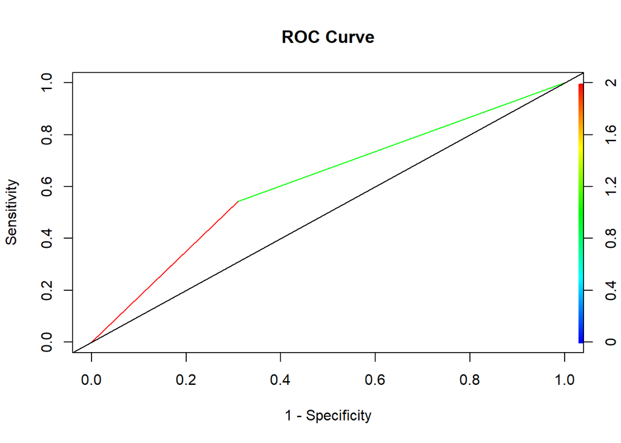

```r
#detach(package:neuralnet)

set.seed(1)
model_svm = svm(label~., data = train,
              kernel = "linear", cost =1, scale = T,
              probability = TRUE,type="C-classification")

test$p <- predict(model_svm, test, type="response")
test$label_roc <- as.numeric(test$label)-1
test$p <- as.numeric(test$p)-1
pr<-prediction(test$p, test$label_roc)
pref <- performance(pr, "tpr", "fpr")
plot(pref, main = "ROC Curve", xlab = "1 - Specificity",  ylab = "Sensitivity",  colorize=TRUE)
abline(0,1)
```

```r
perf_auc = performance(pr, "auc")
as.numeric(perf_auc@y.values)
```

```
## [1] 0.6167513
```

###tree

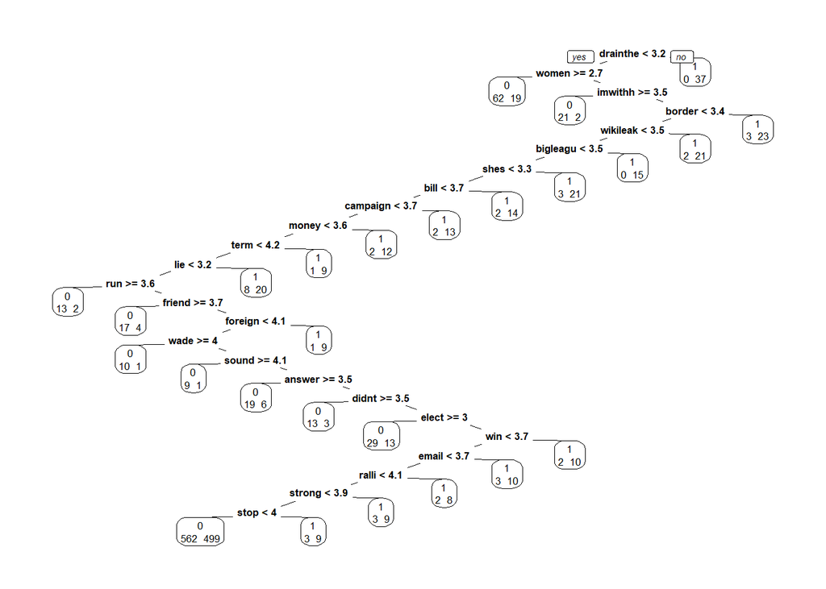

```r
tree = rpart(label ~ ., method = "class", data = train, minbucket = 10, cp = 0)

set.seed(1)
prp(tree, extra = 1)
```

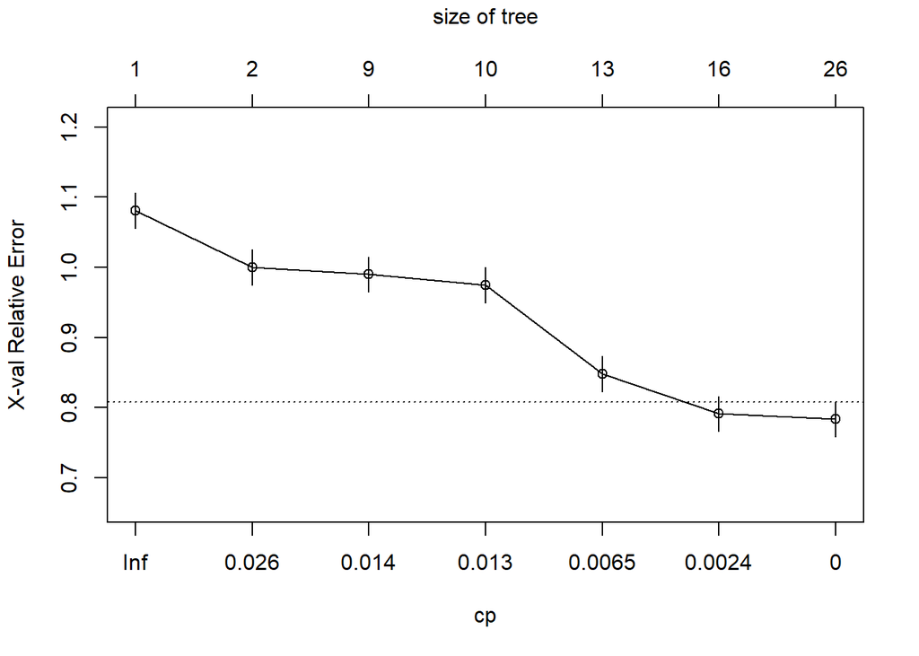

```r
# overplotting
plotcp(tree)
```

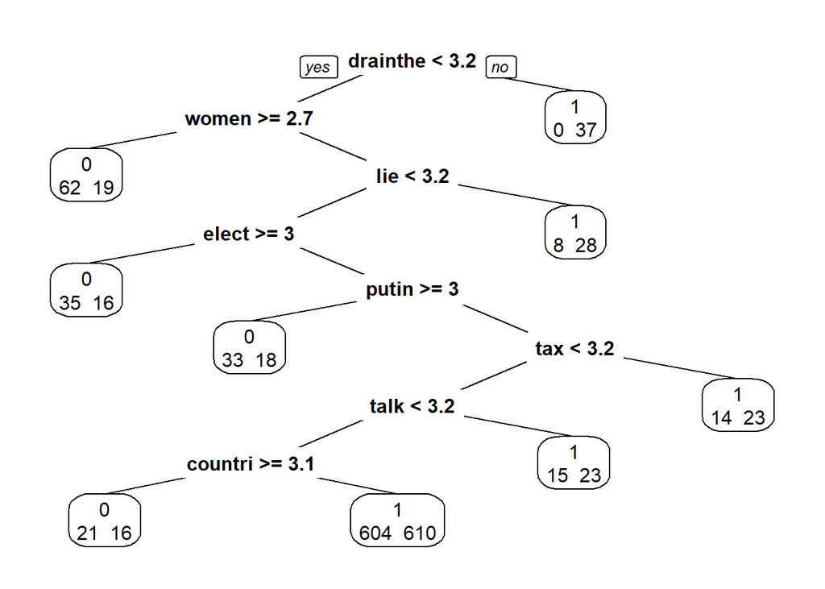

```r
# best cp which is 1 standard deviation below mean is when cp=0
# increase minbucket of tree to make it not overplotting
tree2 = rpart(label ~ ., method = "class", data = train, minbucket = 35, cp = 0)
set.seed(1)
prp(tree2, extra = 1)
```

```r
test$pred_tree = predict(tree2, newdata = test, type="class")
conf_matrix = table(test$label,test$pred_tree)
conf_matrix
```

```
##
##       0   1
##   0  24 173
##   1  14 183
```

```r
sum(diag(conf_matrix))/sum(rowSums(conf_matrix))
```

```
## [1] 0.5253807
```

```r
# Accuracy:0.5253807
# Sensitivity: 183/(183+14) = 0.928934
# Specificity: 24/(24+173) = 0.1218274
# F1 score: 2*(0.928934 * 0.1218274)/(0.928934 + 0.1218274) = 0.215405
```

```r
conclusion <- matrix(c(0.5253807,0.928934,0.1218274,0.215405),ncol=4,byrow=TRUE)
colnames(conclusion) <- c("Accuracy","Sensitivity",
                     "Specificity",
                     "F1 score")
rownames(conclusion) <- 'CART'
conclusion <- as.table(conclusion)
conclusion
```

```
##       Accuracy Sensitivity Specificity  F1 score
## CART 0.5253807   0.9289340   0.1218274 0.2154050
```

Sensitivity being too high and Specificity being too low, make adjustment using loss matrix if we want to increase specificity

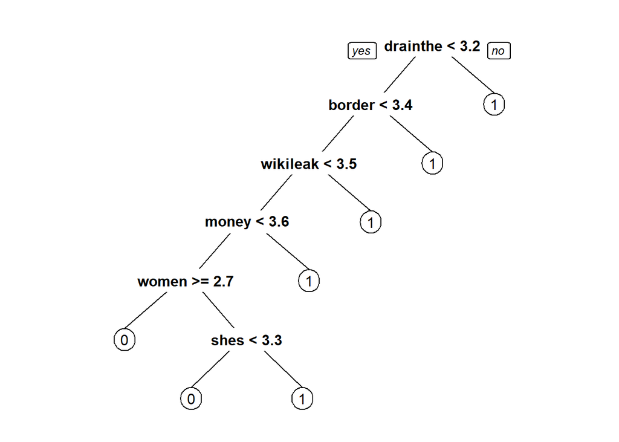

```r
loss_matrix = matrix(c(0, 1, 2.5, 0), nrow=2, ncol=2, byrow = FALSE)

tree_loss = rpart(label ~ .,
                  data = train,
                  method = "class",
                  minbucket=20,
                  parms = list(loss=loss_matrix),
                  cp = 0)
prp(tree_loss)
```

```r
test$pred_loss = predict(tree_loss, newdata = test, type="class")
conf_loss= table(test$label,test$pred_loss)
```

```r
sum(diag(conf_loss))/sum(rowSums(conf_loss))
```

```
## [1] 0.5659898
```

```r
# Accuracy:0.5659898
# Sensitivity: 30/(30+167) = 0.1522843
# Specificity: 193/(193+4) = 0.9796954
# F1 score: 2*(0.1522843 * 0.9796954)/(0.1522843 + 0.9796954) = 0.2635952
```

```r
conclusion <- matrix(c(0.5659898,0.1522843,0.9796954,0.2635952),ncol=4,byrow=TRUE)
colnames(conclusion) <- c("Accuracy","Sensitivity",
                     "Specificity",
                     "F1 score")
rownames(conclusion) <- 'CART applied loss matrix'
conclusion <- as.table(conclusion)
conclusion
```

```
##                           Accuracy Sensitivity Specificity  F1 score
## CART applied loss matrix 0.5659898   0.1522843   0.9796954 0.2635952
```

Bad model compared to the svm, though very good at predicting one of Sensitivity/Specificity alone.

###Logistic

```r
###difficult to compute; logit is not suitable for high dimensional problem

#set.seed(1)
#logit<- ifelse(tweet_exp$follow_candidate=="clinton",1,0)
#logit<-data.frame(label=logit,t(td.mat.w))
#log=glm(label~., data = logit[samp,],family=binomial)
```

```r
#logit_pre<-predict(log,logit[-samp,-1],type="response")
#btest<-floor(logit_pre+0.5)
#conf.matrix = table(tweet_exp[-samp,]$follow_candidate,btest)
#conf.matrix

#sum(diag(conf.matrix))/sum(rowSums(conf.matrix))
```

Therefore, this section, after implementing PCA, extracting top 100 important features, I fit the several models again. comparing the results.

```r
##
dt.mat.w=t(td.mat.w)
dim(dt.mat.w)
```

```
## [1] 1976 2910
```

```r
pca.dt<-prcomp(dt.mat.w, scale=TRUE)
#pca.dt
```

```r
dt.pca=predict(pca.dt)[,1:100]
dim(dt.pca)
```

```
## [1] 1976  100
```

###pca+k_means

```r
set.seed(1)
k_mean_PCA<-kmeans(dt.pca, centers=2, nstart=10)
```

```r
cluster<-cbind(tweet_exp,pred=k_mean_PCA$cluster)
tab<-table(k_mean_PCA$cluster,tweet_exp$follow_candidate)
tab
```

```
##
##     clinton trump
##   1     988   987
##   2       1     0
```

```r
sum(diag(tab))/sum(rowSums(tab))
```

```
## [1] 0.5
```

```r
# Accuracy:0.5
# Sensitivity: 0
# Specificity: 988/(988+987) = 0.5002532
# F1 score: 0
```

```r
conclusion <- matrix(c(0.5,0,0.5002532,0),ncol=4,byrow=TRUE)
colnames(conclusion) <- c("Accuracy","Sensitivity",
                     "Specificity",
                     "F1 score")
rownames(conclusion) <- 'pca_kmeans'
conclusion <- as.table(conclusion)
conclusion
```

```
##             Accuracy Sensitivity Specificity  F1 score
## pca_kmeans 0.5000000   0.0000000   0.5002532 0.0000000
```

###pca+svm

```r
set.seed(1)
library(e1071)
svm<-data.frame(label=as.factor(tweet_exp$follow_candidate),dt.pca)
#samp=sample(nrow(dt.pca),nrow(dt.pca)*0.8)

svm$label = ifelse(svm$label=="clinton", 0 , 1)

svm$label <- factor(svm$label)

set.seed(1)
split <- initial_split(svm, prop = 0.8,
                       strata = 'label')
set.seed(1)
train <- training(split)
set.seed(1)
test <- testing(split)

set.seed(1)
model_PCA = svm(label ~ ., data = train,
              kernel = "linear")
```

```r
svm_pre<-predict(model_PCA,test)
tab<-table(svm_pre,test$label)
#table(tweet[-samp,]$follow_candidate)
tab
```

```
##
## svm_pre   0   1
##       0 143 108
##       1  54  89
```

```r
sum(diag(tab))/sum(rowSums(tab))
```

```
## [1] 0.5888325
```

```r
# Accuracy: 0.5888325
# Sensitivity: 89/(89+54) = 0.6223776
# Specificity: 143/(143+108) = 0.5697211
# F1 score: 2*(0.6223776 * 0.5697211)/(0.6223776 + 0.5697211) = 0.5948864
```

```r
conclusion <- matrix(c(0.5888325,0.6223776,0.5697211,0.5948864),ncol=4,byrow=TRUE)
colnames(conclusion) <- c("Accuracy","Sensitivity",
                     "Specificity",
                     "F1 score")
rownames(conclusion) <- 'pca_SVM'
conclusion <- as.table(conclusion)
conclusion
```

```
##          Accuracy Sensitivity Specificity  F1 score
## pca_SVM 0.5888325   0.6223776   0.5697211 0.5948864
```

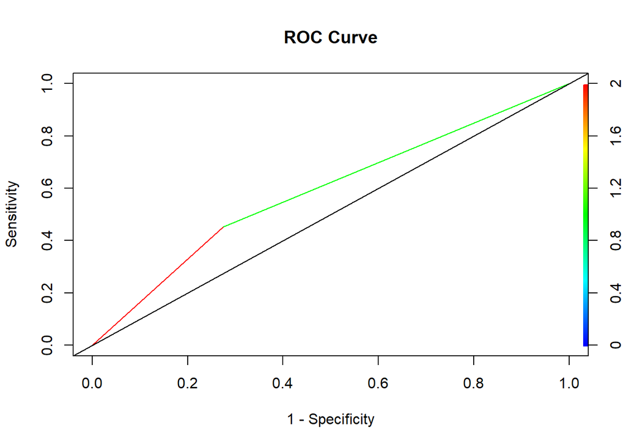

```r
set.seed(1)
model_svm2 = svm(label~., data = train,
              kernel = "linear", cost =1, scale = T,
              probability = TRUE,type="C-classification")

test$p2 <- predict(model_svm2, test, type="response")

test$label_roc2 <- as.numeric(test$label)-1
test$p2 <- as.numeric(test$p2)-1
pr2<-prediction(test$p2, test$label_roc2)
pref2 <- performance(pr2, "tpr", "fpr")
plot(pref2, main = "ROC Curve", xlab = "1 - Specificity",  ylab = "Sensitivity",  colorize=TRUE)
abline(0,1)
```

```r
perf_auc2 = performance(pr2, "auc")
as.numeric(perf_auc2@y.values)
```

```
## [1] 0.5888325
```

###pca+logistic

```r
set.seed(1)
logit<- as.factor(tweet_exp$follow_candidate)#ifelse(tweet$follow_candidate=="clinton",1,0)
logit<-data.frame(label=logit,dt.pca)
#samp=sample(nrow(dt.pca),nrow(dt.pca)*0.8)

logit$label = ifelse(logit$label=="clinton", 0 , 1)

logit$label <- factor(logit$label)

set.seed(1)
split <- initial_split(logit, prop = 0.8,
                       strata = 'label')
set.seed(1)
train <- training(split)
set.seed(1)
test <- testing(split)

set.seed(1)
log=glm(label~., data = train, family=binomial, maxit = 100)
```

```r
logit_pre<-predict(log,test,type="response")

btest<-floor(logit_pre+0.5)

conf.matrix = table(test$label,btest)
conf.matrix
```

```
##    btest
##       0   1
##   0 131  66
##   1 109  88
```

```r
sum(diag(conf.matrix))/sum(rowSums(conf.matrix))
```

```
## [1] 0.5558376
```

```r
# Accuracy: 0.5558376
# Sensitivity: 88/(88+109) = 0.4467005
# Specificity: 131/(131+66) = 0.6649746
# F1 score: 2*(0.4467005 * 0.6649746)/(0.4467005 + 0.6649746) = 0.5344088
```

```r
conclusion <- matrix(c(0.5558376,0.4467005,0.6649746,0.5344088),ncol=4,byrow=TRUE)
colnames(conclusion) <- c("Accuracy","Sensitivity",
                     "Specificity",
                     "F1 score")
rownames(conclusion) <- 'pca_logistic'
conclusion <- as.table(conclusion)
conclusion
```

```
##               Accuracy Sensitivity Specificity  F1 score
## pca_logistic 0.5558376   0.4467005   0.6649746 0.5344088
```

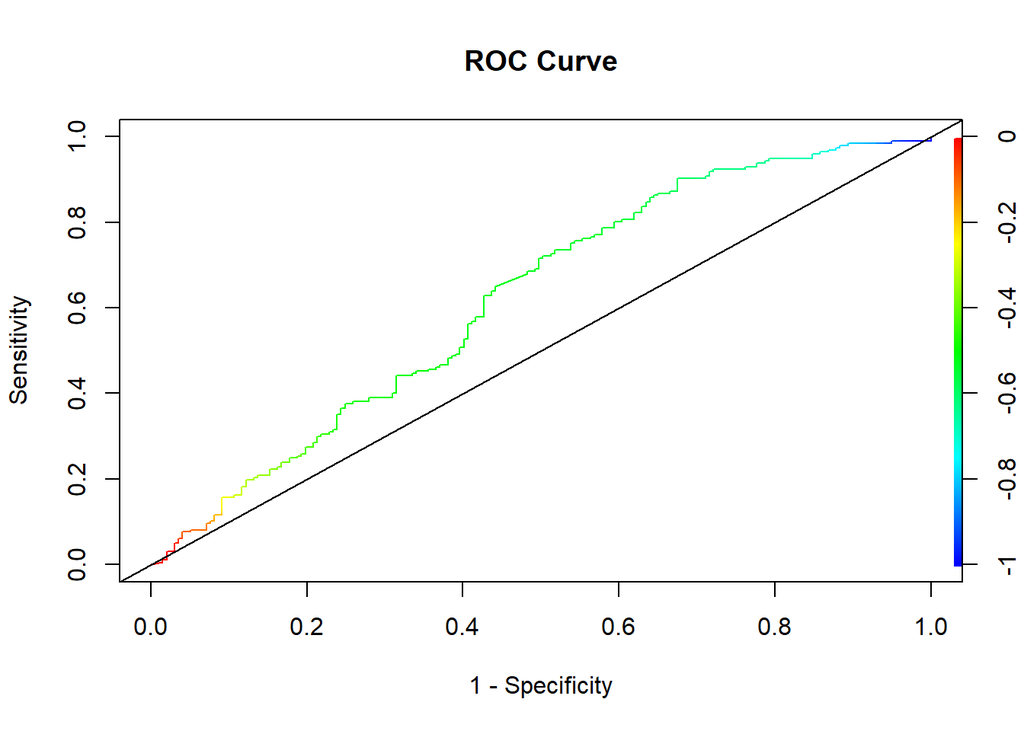

```r
set.seed(1)
model_logit = glm(label~., data = train,
              family=binomial)

test$l <- predict(model_logit, test, type="response")

test$label_roc3 <- as.numeric(test$label)-1
test$l <- as.numeric(test$l)-1
prl<-prediction(test$l, test$label_roc3)
prefl <- performance(prl, "tpr", "fpr")
plot(prefl, main = "ROC Curve", xlab = "1 - Specificity",  ylab = "Sensitivity",  colorize=TRUE)
abline(0,1)
```

```r
perf_aucl = performance(prl, "auc")
as.numeric(perf_aucl@y.values)
```

```
## [1] 0.6206421
```

AUC value: 0.6206421

### neural network

```r
ctrl_k05_roc <- trainControl(method ='cv',number=5 ,
                             summaryFunction = twoClassSummary,
                             classProbs = TRUE,
                             savePredictions = TRUE)
```

```r
library(neuralnet)
set.seed(1)
logit<- as.factor(tweet_exp$follow_candidate)#ifelse(tweet$follow_candidate=="clinton",1,0)
logit<-data.frame(label=logit,dt.pca)
set.seed(1)
fit_nnet <- train(label ~ ., data = logit,
                          method = "nnet",
                          metric = 'ROC',
                          preProcess = c("center", "scale"),
                          trControl = ctrl_k05_roc,
                        trace = FALSE)
fit_nnet
```

```
## Neural Network
##
## 1976 samples
##  100 predictor
##    2 classes: 'clinton', 'trump'
##
## Pre-processing: centered (100), scaled (100)
## Resampling: Cross-Validated (5 fold)
## Summary of sample sizes: 1580, 1581, 1581, 1581, 1581
## Resampling results across tuning parameters:
##
##   size  decay  ROC        Sens       Spec
##   1     0e+00  0.6237088  0.6651131  0.5631441
##   1     1e-04  0.6152711  0.5743168  0.6170538
##   1     1e-01  0.6285382  0.5591396  0.6423627
##   3     0e+00  0.6235344  0.5612367  0.6270164
##   3     1e-04  0.6409704  0.5722658  0.6534995
##   3     1e-01  0.6334486  0.5692970  0.6281803
##   5     0e+00  0.6263246  0.5883556  0.5774240
##   5     1e-04  0.6520488  0.6654310  0.5532277
##   5     1e-01  0.6192705  0.5490130  0.6120084
##
## ROC was used to select the optimal model using the largest value.
## The final values used for the model were size = 5 and decay = 1e-04.
```

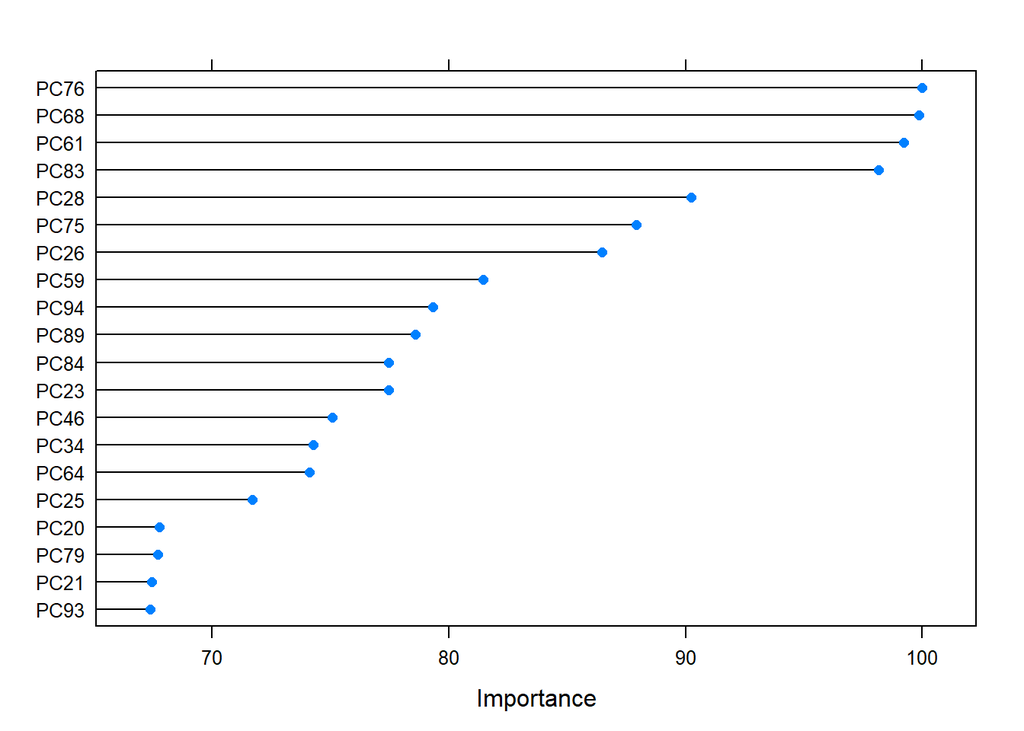

```r
plot(varImp(fit_nnet), top = 20)
```

```r
#fit_nnet$bestTune

tab = (fit_nnet$pred )%>%filter(size == fit_nnet$bestTune$size,decay==fit_nnet$bestTune$decay)
tab= table(tab$obs,tab$pred)
tab
```

```
##
##           clinton trump
##   clinton     658   331
##   trump       441   546
```

```r
accuracy = (sum(diag(tab)))/sum(tab)
cat('accuracy: ',accuracy)
```

```
## accuracy:  0.6093117
```

```r
p = tab[1,1]/(tab[1,1]+tab[2,1])
r = tab[1,1]/(tab[1,1]+tab[1,2])
f1 = (2*p*r)/(p+r)
cat('\nF1:',f1)
```

```
##
## F1: 0.6302682
```

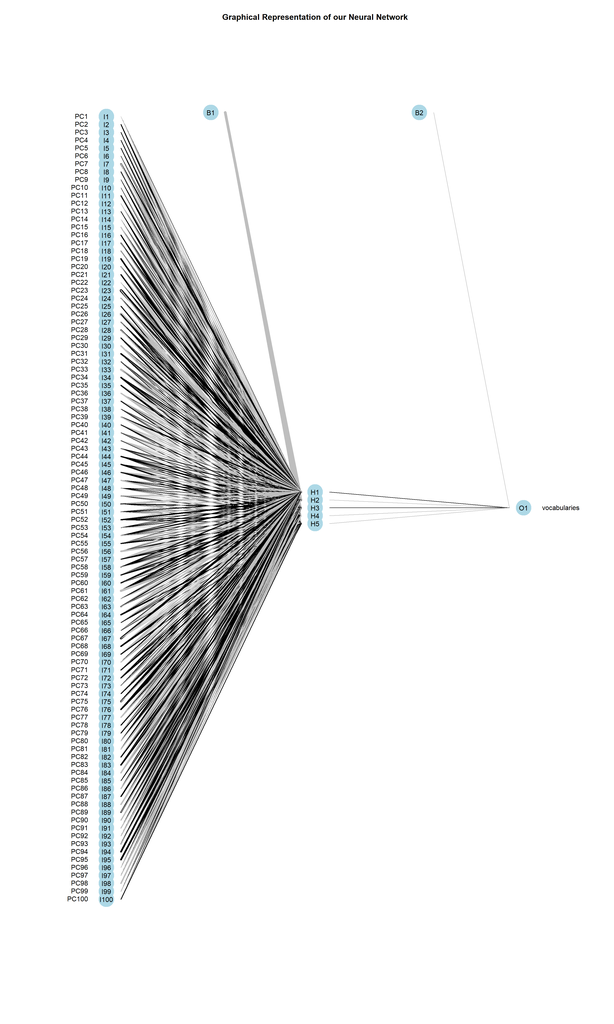

```r
library(nnet)
library(NeuralNetTools)
plotnet(fit_nnet$finalModel, y_names = "vocabularies")
title("Graphical Representation of our Neural Network")
```

### random forest

```r
set.seed(4321)
data=data.frame(label=tweet_exp$follow_candidate,dt.pca)
fit_rf <- train(label ~ ., data =data,
                       method = "rf", trControl = ctrl_k05_roc ,metric = "ROC",
                      importance = TRUE)

fit_rf
```

```
## Random Forest
##
## 1976 samples
##  100 predictor
##    2 classes: 'clinton', 'trump'
##
## No pre-processing
## Resampling: Cross-Validated (5 fold)
## Summary of sample sizes: 1581, 1581, 1581, 1581, 1580
## Resampling results across tuning parameters:
##
##   mtry  ROC        Sens       Spec
##     2   0.7127792  0.6805158  0.6169410
##    51   0.7184402  0.6865816  0.6199764
##   100   0.7118406  0.6956878  0.6088448
##
## ROC was used to select the optimal model using the largest value.
## The final value used for the model was mtry = 51.
```

```r
tab = (fit_rf$pred )%>%filter(mtry == fit_rf$bestTune$mtry)
tab= table(tab$obs,tab$pred)
tab
```

```
##
##           clinton trump
##   clinton     679   310
##   trump       375   612
```

```r
accuracy = (sum(diag(tab)))/sum(tab)
cat('accuracy: ',accuracy)
```

```
## accuracy:  0.6533401
```

```r
p = tab[1,1]/(tab[1,1]+tab[2,1])
r = tab[1,1]/(tab[1,1]+tab[1,2])
f1 = (2*p*r)/(p+r)
cat('\nF1:',f1)
```

```
##
## F1: 0.6647088
```

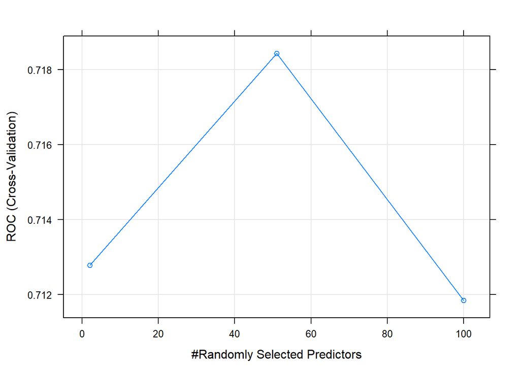

```r
plot(fit_rf)
```

### classification tree

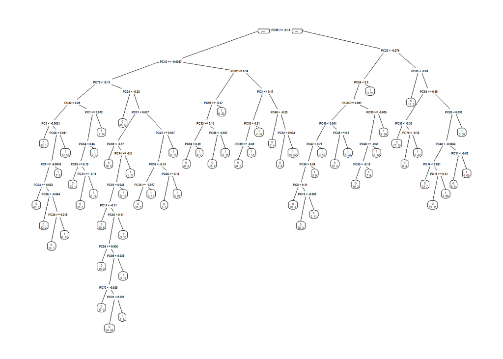

```r
set.seed(1)
logit<- as.factor(tweet_exp$follow_candidate)#ifelse(tweet$follow_candidate=="clinton",1,0)
logit<-data.frame(label=logit,dt.pca)
#samp=sample(nrow(dt.pca),nrow(dt.pca)*0.8)

logit$label = ifelse(logit$label=="clinton", 0 , 1)

logit$label <- factor(logit$label)

set.seed(1)
split <- initial_split(logit, prop = 0.8,
                       strata = 'label')
set.seed(1)
train <- training(split)
set.seed(1)
test <- testing(split)

tree = rpart(label ~ ., method = "class", data = train, minbucket = 10, cp = 0)

set.seed(1)
prp(tree, extra = 1)
```

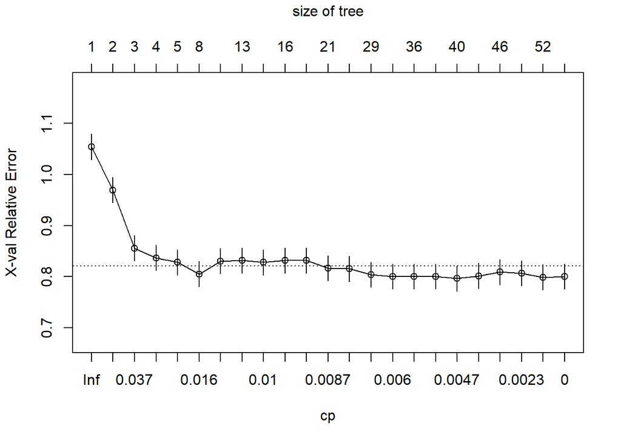

```r
# overplotting
plotcp(tree)
```

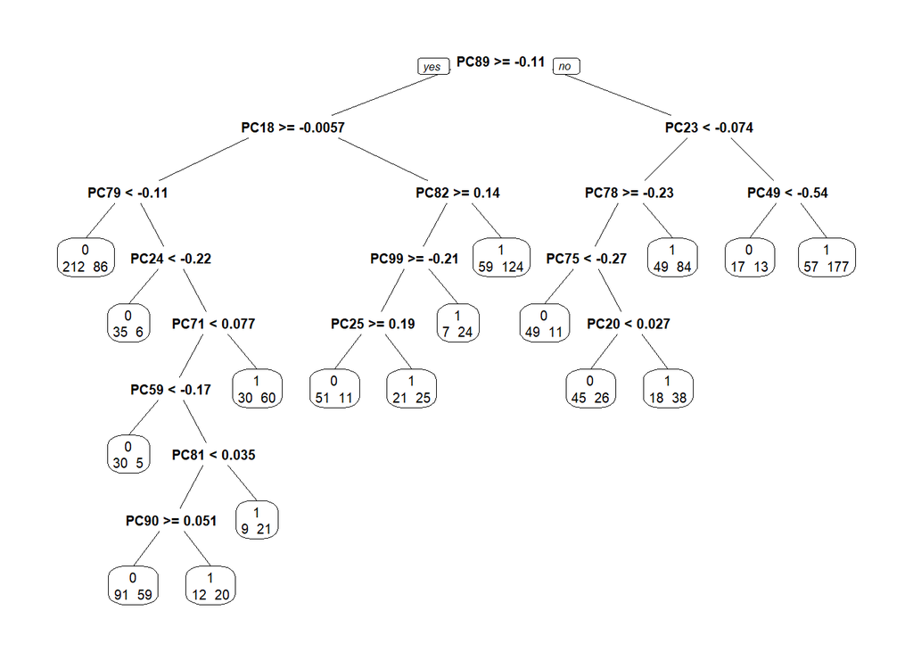

```r
# best cp which is 1 standard deviation below mean is when cp=0.0047
# increase minbucket of tree to make it not overplotting
tree2 = rpart(label ~ ., method = "class", data = train, minbucket = 30, cp = 0.0047)
set.seed(1)
prp(tree2, extra = 1)
```

```r
test$pred_tree2 = predict(tree2, newdata = test, type="class")
conf_matrix = table(test$label,test$pred_tree2)
conf_matrix
```

```
##
##       0   1
##   0 106  91
##   1  77 120
```

```r
sum(diag(conf_matrix))/sum(rowSums(conf_matrix))
```

```
## [1] 0.5736041
```

```r
# Accuracy:0.5736041
# Sensitivity: 120/(120+77) = 0.6091371
# Specificity: 106/(106+91) = 0.5380711
# F1 score: 2*(0.6091371 * 0.5380711)/(0.6091371 + 0.5380711) = 0.5714029
```

```r
conclusion <- matrix(c(0.5736041,0.6091371,0.5380711,0.5714029),ncol=4,byrow=TRUE)
colnames(conclusion) <- c("Accuracy","Sensitivity",
                     "Specificity",
                     "F1 score")
rownames(conclusion) <- 'pca_CART'
conclusion <- as.table(conclusion)
conclusion
```

```
##           Accuracy Sensitivity Specificity  F1 score
## pca_CART 0.5736041   0.6091371   0.5380711 0.5714029
```

way better than it is in the non-pca data. Still generally worse than svm. However, the area under curve is larger in logistic regression than it in svm.

## The second feature—sentiment

From the result above, we found that TF-IDF, as a input feature, does not work well in several. Therefore, we introduce new variables to improve the performance of our models.  
After data exploration, we found that supporters show more positive attitudes toward their favorite candidates, meanwhile, they show more negative attitudes toward candidates they don’t like. By measure the sentiment of text, we can get one more feature indicating the attitude of the publisher towards certain candidates.

####pre_processing

```r
f2corpus = Corpus(VectorSource(tweet_exp$text))
f2corpus = CleanCorpus(f2corpus)
#corpus=RemoveNames(corpus)
```

```r
text=(content(f2corpus))
text=trimws(text, which = c("left"), whitespace = "[ \t\r\n]")
text=list(strsplit(text, " "))
#text
```

```r
Sent<-data.frame(Trump_sent=rep(0,length(content(f2corpus))),Clinton_sent=rep(0,length(content(f2corpus))))
```

```r
deny = c('never','not','do',"no","nor","isnt","arent","wasnt","werent" ,"hasnt","havent","hadnt","doesnt" ,   "dont","didnt","wont" ,"wouldnt" ,  "shant","shouldnt" ,"cant","cannot","couldnt", "mustnt",'hardly','nobody', 'without','few')
def = data.frame(word = c('abort','abortion','tax','killer','lie','question','answer'),value =c(-2,-2,-1,-2,-2,-1,1))
```

###sentiment extraction

```r
for(i in seq(1,length(content(f2corpus)))){

 # print(i)
    list_text=data.frame(word=text[[1]][[i]])
    #print(list_text)
  #
    len_text = nrow(list_text)
    afinn_new = rbind(get_sentiments("afinn"),def)
    score = list_text %>% inner_join(afinn_new, by="word")
    count = table(score$word)
    current=table(score$word)

  if (nrow(score)!=0)
    {for (j in (1:nrow(score))){
      #print(score$word[j])
      item = score$word[j]
      #print(list_text$word==score$word[j])
      index=which(list_text$word==score$word[j])[1+count[item]-current[item]]
      current[item] = current[item]-1


      for (k in seq(1,(len_text-1))){

        if ((index-k) %in% (1:len_text)){
          if(list_text$word[index-k] %in% Trump){
            Sent[i,1] = Sent[i,1]+score$value[j]
            break
          }
          if(list_text$word[index-k] %in% Clinton){
            Sent[i,2] = Sent[i,2]+score$value[j]
            break
          }
        }

        if ((index+k) %in% (1:len_text)){
          if(list_text$word[index+k] %in% Trump){
            Sent[i,1] =Sent[i,1]+ score$value[j]
            break
          }
          if(list_text$word[index+k] %in% Clinton){
            Sent[i,2] = Sent[i,2]+score$value[j]
            break
          }
        }


      }


    }}

 if(length(intersect(unlist(list(list_text$word)),deny))!=0)
 {
   sect = intersect(unlist(list(list_text$word)),deny)
   loc_C = which(unlist(list(list_text$word)) %in% Clinton)
   loc_T=which(unlist(list(list_text$word)) %in% Trump)

   loc= which(unlist(list(list_text$word)) %in% sect)

   if(length(loc_C)!=0 || length(loc_C)!=0 )
   {
     for (l in (1:length(sect))){
     if (min(loc_C-loc[l])>min(loc_T-loc[l]))
     {
       Sent[i,1] = (-1)*Sent[i,1]
     }
     else{
       Sent[i,2] = (-1)*Sent[i,1]
     }

   }

   }


 }
}
```

###prediction Predicting political leanings through sentiment

```r
head(Sent,length(content(f2corpus)))
```

```
##      Trump_sent Clinton_sent
## 1             0            0
## 2             0            0
## 3             0            0
## 4             0            0
## 5            -2            0
## 6             0            0
## 7            -7            0
## 8             0            0
## 9             0            0
## 10            0           -2
## 11            0            0
## 12           -2            0
## 13            2            0
## 14           -2            0
```

[output cut: 1962 more lines]

```r
flag = Sent$Trump_sent-Sent$Clinton_sent
#flag = ifelse((flag>0),"Trump",'Clinton')
a=Sent%>%mutate(pre = ifelse((flag<=0),'clinton',"trump"))
a=a[1:length(content(f2corpus)),]
#a
All = data.frame(a,label=tweet_exp[1:length(content(f2corpus)),]$follow_candidate)
#All
tab=table(All$pre,All$label)
tab
```

```
##
##           clinton trump
##   clinton     841   725
##   trump       148   262
```

```r
sum(diag(tab))/length(content(f2corpus))
```

```
## [1] 0.5581984
```

##Feature combination (f1+f2)

```r
dim(dt.pca)
```

```
## [1] 1976  100
```

```r
dim(Sent)
```

```
## [1] 1976    2
```

```r
F= cbind(Sent,dt.pca)
dim(F)
```

```
## [1] 1976  102
```

## Model fit

Since random forest,SVM have relatively good performance in the previous stage, we continued to use RF for prediction.

### random forest

```r
set.seed(4321)
data=data.frame(label=tweet_exp$follow_candidate,F)
fit_rf <- train(label ~ ., data =data,
                       method = "rf", trControl = ctrl_k05_roc ,metric = "ROC",
                      importance = TRUE)

fit_rf
```

```
## Random Forest
##
## 1976 samples
##  102 predictor
##    2 classes: 'clinton', 'trump'
##
## No pre-processing
## Resampling: Cross-Validated (5 fold)
## Summary of sample sizes: 1581, 1581, 1581, 1581, 1580
## Resampling results across tuning parameters:
##
##   mtry  ROC        Sens       Spec
##     2   0.7252978  0.6886376  0.6362098
##    52   0.7343155  0.7037840  0.6240783
##   102   0.7285477  0.7088192  0.6129313
##
## ROC was used to select the optimal model using the largest value.
## The final value used for the model was mtry = 52.
```

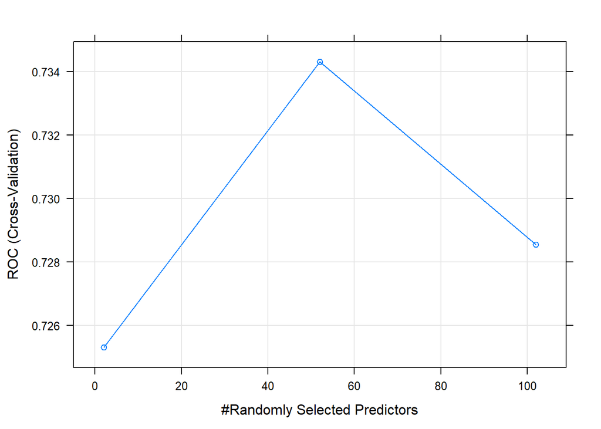

```r
plot(fit_rf)
```

```r
#fit_rf$bestTune$mtry
tab = (fit_rf$pred )%>%filter(mtry == fit_rf$bestTune$mtry)
tab= table(tab$obs,tab$pred)
tab
```

```
##
##           clinton trump
##   clinton     696   293
##   trump       371   616
```

```r
accuracy = (sum(diag(tab)))/sum(tab)
cat('accuracy: ',accuracy)
```

```
## accuracy:  0.6639676
```

```r
p = tab[1,1]/(tab[1,1]+tab[2,1])
r = tab[1,1]/(tab[1,1]+tab[1,2])
f1 = (2*p*r)/(p+r)
cat('\nF1:',f1)
```

```
##
## F1: 0.6770428
```

###svm

```r
set.seed(1)
library(e1071)
svm<-data.frame(label=as.factor(tweet_exp$follow_candidate),F)


svm$label = ifelse(svm$label=="clinton", 0 , 1)

svm$label <- factor(svm$label)

set.seed(1)
split <- initial_split(svm, prop = 0.8,
                       strata = 'label')
set.seed(1)
train <- training(split)
set.seed(1)
test <- testing(split)


#samp=sample(nrow(F),nrow(F)*0.8)
model_PCA <- svm(label~., data = train,kernel='linear')
```

```r
svm_pre<-predict(model_PCA,test)
tab<-table(svm_pre,test$label)
#table(tweet[-samp,]$follow_candidate)
tab
```

```
##
## svm_pre   0   1
##       0 150 120
##       1  47  77
```

```r
print("Accuracy")
```

```
## [1] "Accuracy"
```

```r
sum(diag(tab))/sum(rowSums(tab))
```

```
## [1] 0.5761421
```

```r
# Sensitivity: 77/(77+47) = 0.6209677
# Specificity: 150/(150+120) = 0.5555556
# F1 score: 2*(0.6209677 * 0.5555556)/(0.6209677 + 0.5555556) = 0.5864433
```

```r
conclusion <- matrix(c(0.5888325,0.6209677,0.5555556,0.5864433),ncol=4,byrow=TRUE)
colnames(conclusion) <- c("Accuracy","Sensitivity",
                     "Specificity",
                     "F1 score")
rownames(conclusion) <- 'pca_senti_SVM'
conclusion <- as.table(conclusion)
conclusion
```

[output not shown]

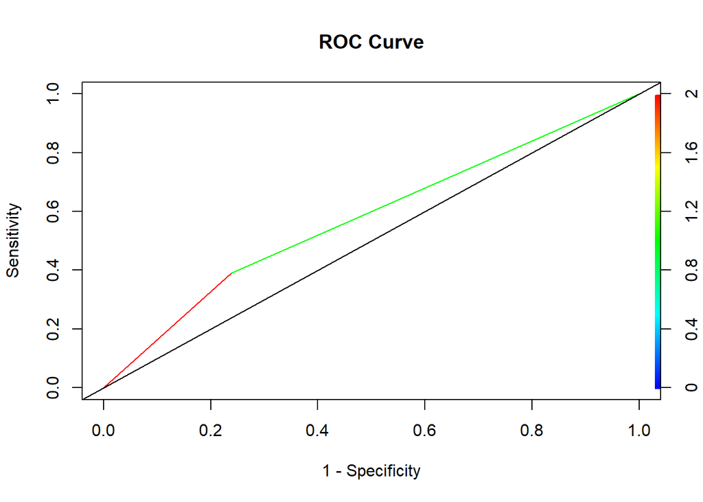

```r
detach(package:neuralnet)
set.seed(1)
model_svm_final = svm(label~., data = train,kernel='linear')
test$svm <- predict(model_svm_final, test, type="response")

test$label_roc_svm <- as.numeric(test$label)-1
test$svm_f <- as.numeric(test$svm)-1
pr_scv<-prediction(test$svm_f, test$label_roc_svm)
pref_svm <- performance(pr_scv, "tpr", "fpr")
plot(pref_svm, main = "ROC Curve", xlab = "1 - Specificity",  ylab = "Sensitivity",  colorize=TRUE)
abline(0,1)
```

```r
perf_auc_svm = performance(pr_scv, "auc")
as.numeric(perf_auc_svm@y.values)
```

```
## [1] 0.5761421
```

###logit

```r
set.seed(1)
library(e1071)
logit<-data.frame(label=as.factor(tweet_exp$follow_candidate),F)


logit$label = ifelse(logit$label=="clinton", 0 , 1)

logit$label <- factor(logit$label)

set.seed(1)
split <- initial_split(logit, prop = 0.8,
                       strata = 'label')
set.seed(1)
train <- training(split)
set.seed(1)
test <- testing(split)


#samp=sample(nrow(F),nrow(F)*0.8)
model_logit <- glm(label~., data = train, family='binomial', maxit=100)
```

```r
logit_pre<-predict(model_logit, test)
tab<-table(logit_pre, test$label)
#table(tweet[-samp,]$follow_candidate)
print("Accuracy")
```

```
## [1] "Accuracy"
```

```r
sum(diag(tab))/sum(rowSums(tab))
```

```
## [1] 0.002538071
```

Accuracy is too low, we won’t consider this model under current data.

###neural network

```r
set.seed(4321)
data = data.frame(label=tweet_exp$follow_candidate,F)
fit_nnet <- train(label ~ ., data = data,
                          method = "nnet",
                          metric = 'ROC',
                          preProcess = c("center", "scale"),
                          trControl = ctrl_k05_roc,
                        trace = FALSE)

fit_nnet
```

```
## Neural Network
##
## 1976 samples
##  102 predictor
##    2 classes: 'clinton', 'trump'
##
## Pre-processing: centered (102), scaled (102)
## Resampling: Cross-Validated (5 fold)
## Summary of sample sizes: 1581, 1581, 1581, 1581, 1580
## Resampling results across tuning parameters:
##
##   size  decay  ROC        Sens       Spec
##   1     0e+00  0.6171415  0.6369738  0.5804851
##   1     1e-04  0.6083246  0.6814746  0.4993591
##   1     1e-01  0.6377688  0.5975388  0.6220787
##   3     0e+00  0.6255285  0.6138594  0.5806389
##   3     1e-04  0.6406426  0.5823668  0.6291545
##   3     1e-01  0.6377149  0.6217813  0.5713172
##   5     0e+00  0.6321193  0.5925242  0.6129519
##   5     1e-04  0.6230166  0.6218530  0.5502282
##   5     1e-01  0.6471131  0.6097165  0.6220992
##
## ROC was used to select the optimal model using the largest value.
## The final values used for the model were size = 5 and decay = 0.1.
```

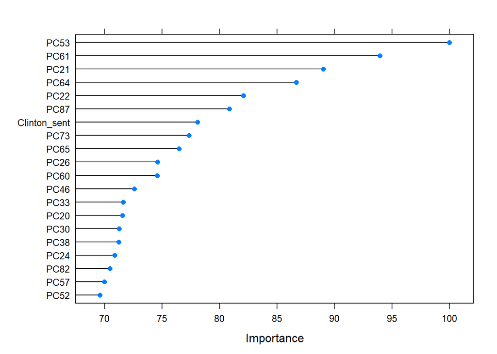

```r
plot(varImp(fit_nnet), top = 20)
```

```r
##nnet_accuracy and F1
tab = (fit_nnet$pred )%>%filter(size == fit_nnet$bestTune$size,decay==fit_nnet$bestTune$decay)
tab= table(tab$obs,tab$pred)
tab
```

```
##
##           clinton trump
##   clinton     603   386
##   trump       373   614
```

```r
accuracy = (sum(diag(tab)))/sum(tab)
cat('accuracy: ',accuracy)
```

```
## accuracy:  0.6158907
```

```r
p = tab[1,1]/(tab[1,1]+tab[2,1])
r = tab[1,1]/(tab[1,1]+tab[1,2])
f1 = (2*p*r)/(p+r)
cat('\nF1:',f1)
```

```
##
## F1: 0.6137405
```

[figure not shown]

```r
library(nnet)
library(NeuralNetTools)
plotnet(fit_nnet$finalModel, y_names = "vocabularies")
title("Graphical Representation of our Neural Network")
```

```r
conclusion <- matrix(c(0.500,0.5,0.5005,0.5002,'NA',0.5,0,0.5002,0,'NA',0.555,0.446,0.664,0.534,'NA',0.525,0.928,0.121,0.215,'NA',0.573,0.609,0.538,0.571,'NA',0.616,0.636,0.601,0.618,'NA',0.588,0.622,0.569,0.594,'NA',0.576,0.620,0.555,0.586,'NA',0.653,0.686,0.619,0.664,0.718,0.663,0.703,0.624,0.677,0.734,0.609,0.665,0.553,0.630,0.652,0.615,0.609,0.622,0.613,0.647),ncol=5,byrow=TRUE)
rownames(conclusion) <- c("kmeans(TDM)","kmeans(TDM+PCA)",
                     "logistic(TDM+PCA)",
                     "classification tree(TDM)","classification tree(TDM+PCA)",
                     "svm(TDM)","svm(TDM+PCA)","svm(TDM+PCA+sentiment)",
                     "random forest(TDM+PCA)","random forest(TDM+PCA+sentiment)",
                     "neural network(TDM+PCA)","neural network(TDM+PCA+sentiment)")

colnames(conclusion) <- c("Accuracy","Sensitivity","Specificity","F1 score","ROC")
conclusion <- as.table(conclusion)
conclusion
```

```
##                                   Accuracy Sensitivity Specificity F1 score
## kmeans(TDM)                       0.5      0.5         0.5005      0.5002
## kmeans(TDM+PCA)                   0.5      0           0.5002      0
## logistic(TDM+PCA)                 0.555    0.446       0.664       0.534
## classification tree(TDM)          0.525    0.928       0.121       0.215
## classification tree(TDM+PCA)      0.573    0.609       0.538       0.571
## svm(TDM)                          0.616    0.636       0.601       0.618
## svm(TDM+PCA)                      0.588    0.622       0.569       0.594
## svm(TDM+PCA+sentiment)            0.576    0.62        0.555       0.586
## random forest(TDM+PCA)            0.653    0.686       0.619       0.664
## random forest(TDM+PCA+sentiment)  0.663    0.703       0.624       0.677
## neural network(TDM+PCA)           0.609    0.665       0.553       0.63
## neural network(TDM+PCA+sentiment) 0.615    0.609       0.622       0.613
##                                   ROC
## kmeans(TDM)                       NA
## kmeans(TDM+PCA)                   NA
## logistic(TDM+PCA)                 NA
## classification tree(TDM)          NA
## classification tree(TDM+PCA)      NA
## svm(TDM)                          NA
## svm(TDM+PCA)                      NA
## svm(TDM+PCA+sentiment)            NA
## random forest(TDM+PCA)            0.718
## random forest(TDM+PCA+sentiment)  0.734
## neural network(TDM+PCA)           0.652
## neural network(TDM+PCA+sentiment) 0.647
```